# PCA & UMAP

2019-12-28

I’m going to try something like [this](https://colah.github.io/posts/2014-10-Visualizing-MNIST/).

I will use a sample of the MNIST digit dataset that is in the keras library (i will not use keras here).

```r
#nowt gona use keras, is just to get the minst data set
library(keras)
mnist <- dataset_mnist()
x_train <- mnist$train$x
y_train <- mnist$train$y
x_test <- mnist$test$x
y_test <- mnist$test$y

dim(x_train) <- c(nrow(x_train),784)
dim(x_test)  <- c(nrow(x_test),784)

#and i'm going to use a small sample to speed up things
set.seed(123)
id <- sample(1:nrow(x_train),size = 12000,replace = F)
x_train <- x_train[id,]
y_train <- y_train[id]
```

# PCA

If I have to explain in a high level perspective, super-approximated, what a PCA does: It creates 2 spaces, that correspond to distance between lines of a matrix (points or observations) and other that correspond to the correlation between columns of the same matrix (variables). One is the dual space of the other, and math-magic you can plot both in the same graph. An important fact of PCA is that it keeps ALL information of the matrix, so if you take all components, you can reproduce the full matrix. What information?: distance between points and correlation between columns. So you can not plug any matrix in a PCA, but a *model* *matrix* where each row is a individual object and each columns is a variable. So a matrix that defines a image, is not suited for PCA. Let’s see this with an example:

This is a matrix with a “one” ready to be ploted with ggimage():

$$\begin{bmatrix}
0 & 0 & 0 & 0 & 0 & 0\\
0 & 0 & 1 & 1 & 0 & 0\\
0 & 0 & 1 & 1 & 0 & 0\\
0 & 0 & 1 & 1 & 0 & 0\\
0 & 0 & 1 & 1 & 0 & 0\\
0 & 0 & 0 & 0 & 0 & 0
\end{bmatrix}$$
And this is the same data, but as a single row of a *model matrix* ready to be fed into a PCA:
$$\begin{bmatrix}
X1 & ... & X6 & X7 & X8 & X9 & X10 & X11 & X12 & ... & X36\\
0& ... & 0 & 0 & 0 & 1 & 1 & 0 & 0 & ... & 0 &\end{bmatrix}$$

## Image Matrix vrs Model Matrix

### One’s

What we see: a image matrix of a *one*, versus what PCA “see” (a matrix of 300 ones)

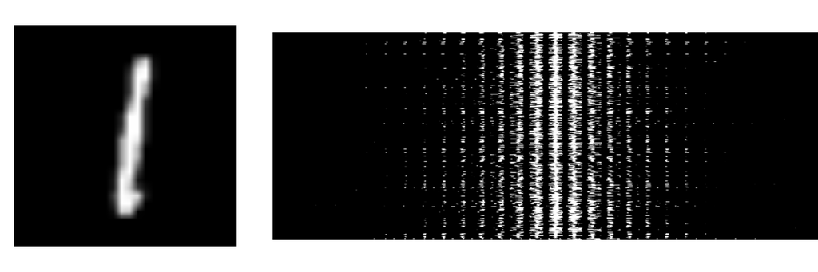

Figure 1: Left: a ggimage() of a *one* in a 28*28 matrix. Rigth: Visual representation of 300 *ones* in a model matrix with 28*28 columns and 300 lines

```r
library(ggmap)
library(gridExtra)
#image of one "one"
id <- which(y_train==1)[2] #pick the second one, because the first is "ugly"
img <- x_train[id,]
img <- t(matrix(img, nrow=28L, byrow=T))
p0 <- ggimage(img)+theme(plot.margin = unit(c(0.4,1,0.4,0.4), "cm"))
#matrix of 300 ones
id <- head(which(y_train== 1),300)
img <- x_train[id,]
p1 <- ggimage(img)

grid.arrange(p0,p1,nrow=1,widths=c(2,4))
```

### Zero’s

The same but with a *zero*

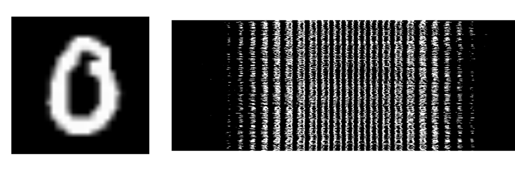

Figure 2: Left: a ggimage() of a *zero* in a 28*28 matrix. Rigth: Visual representation of 300 *zeros* in a model matrix

```r
id <- which(y_train==0)[1]
img <- x_train[id,]
img <- t(matrix(img, nrow=28L, byrow=T))
p0 <- ggimage(img)+theme(plot.margin = unit(c(0.5,1,0.5,0.5), "cm"))
#matrix of 300 zeros
id <- head(which(y_train== 0),300)
img <- x_train[id,]
p1 <- ggimage(img)
grid.arrange(p0,p1,nrow=1,widths=c(2,4))
```

### Both

A visual way to check correlation between different objects, is to overlap the columns, and see how many coincidences they have. Here we will overlap 300 **ones** (in blue) and 300 **zeros** (in red), with the overlaps in white.

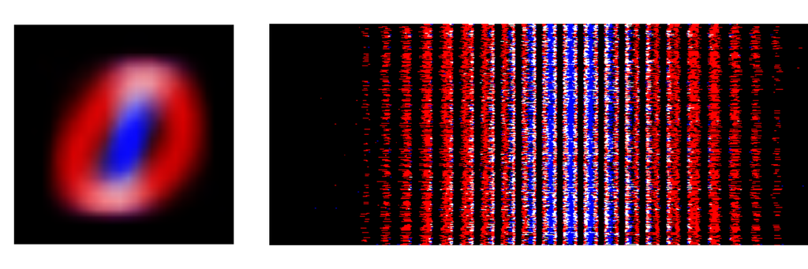

Figure 3: Left: Plot of 300 **ones** (blue) and **zeros** (red) overlaped (white for overlapet areas). Rigth: The same overlap, but in model matrix.

```r
#image
idones <- head(which(y_train == 1),300)
img1 <- x_train[idones,]
dim(img1) <- c(300,28,28)
idzeros <- head(which(y_train == 0),300)
img0 <- x_train[idzeros,]
dim(img0) <- c(300,28,28)
digitoverlap <- array(rep(0,28*28*3), c(28,28,3))
for(i in 1:300){
  for(j in 1:28){
    for(k in 1:28){
    if(img1[i,j,k]>0) digitoverlap[j,k,3] <- digitoverlap[j,k,3]+1
    if(img0[i,j,k]>0) digitoverlap[j,k,1] <- digitoverlap[j,k,1]+1
    if(img1[i,j,k]>0 & img0[i,j,k]>0) digitoverlap[j,k,2] <- digitoverlap[j,k,2]+1 #add white
    }
  }
}
p0 <- ggimage(digitoverlap)+theme(plot.margin = unit(c(0.4,1,0.4,0.4), "cm"))

#model matrix
img1 <- t(x_train[idones,])
img0 <- t(x_train[idzeros,])
matrixoverlap <- array(rep(NA,728*300*3), c( 300,728, 3))
for(i in 1:728){
  for(j in 1:300){
    if(img1[i,j]==0 & img0[i,j]==0) matrixoverlap[j,i,] <- c(0,0,0)
    if(img1[i,j]>0  & img0[i,j]==0) matrixoverlap[j,i,] <- c(0,0,1)
    if(img1[i,j]==0 & img0[i,j]>0)  matrixoverlap[j,i,] <- c(1,0,0)
    if(img1[i,j]>0  & img0[i,j]>0)  matrixoverlap[j,i,] <- c(1,1,1)

  }
}
p1 <- ggimage(matrixoverlap)

grid.arrange(p0,p1,nrow=1,widths=c(2,4))
```

## The PCA

I think is pretty intuitive that the shapes of **1** and **0** are the more uncorrelated ones, ergo they will be in oposites sides of the first component of the PCA:

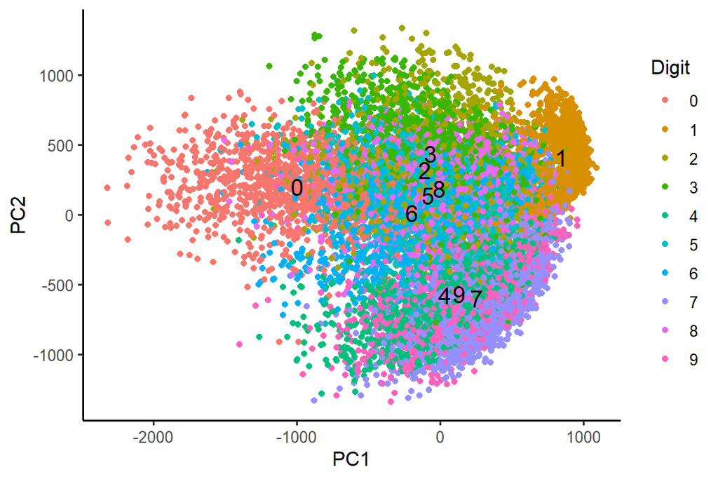

Figure 4: digit-MINST PCA of first 2 components

```r
pca.model <- prcomp(x_train)

pca.df <- data.frame(pca.model$x[,1:2])

pca.df$y_train <- y_train
centroid <- pca.df%>%group_by(y_train)%>%summarise(PC1=mean(PC1),PC2=mean(PC2))

ggplot(pca.df)+geom_point(aes(PC1,PC2,color=factor(y_train)))+
  geom_text(data=centroid,aes(PC1,PC2,label=y_train),size=5)+labs(color='Digit')
```

Remember that PCA keeps the relative distance between individuals, so obviously **0** is far away from **1**, and **5** will be kept close to **6**, **4** close to **9**, etc… But also those 4’s that are more look-alike a **9**, will be more close to the **9** centroid, and **7**’s that are more similar to **1** will be closer to the **1** centroid… That is a lot of information, and requires a lot of axis to keep it, and a lot of granularity to display. Thus the graph looks “fuzzy”, and 2 components is really not enough to display this complexity.  
But it allow us to find the more **1** of the **8**`s, the more **0** of the **8**, and the more **9** …. and with only the 2 first components.

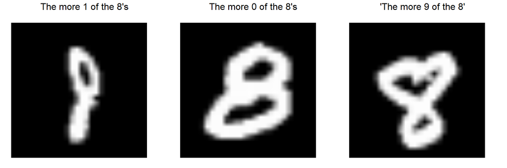

Figure 5: Some 8’s

```r
library(ggmap)
library(gridExtra)

pca.df$id <- 1:nrow(pca.df)
# the more 1 of the 8's
id1 <- (pca.df%>%filter(y_train==8)%>%group_by()%>%filter(PC1==max(PC1)))$id
img <- x_train[id1,]
dim(img) <- c(28,28)
p1 <- ggimage(img)+theme(plot.margin = unit(c(0,1,0,0.5), "cm"))
# the more 0....
id1 <- (pca.df%>%filter(y_train==8)%>%group_by()%>%filter(PC1==min(PC1)))$id
img <- x_train[id1,]
dim(img) <- c(28,28)
p0 <- ggimage(img)+theme(plot.margin = unit(c(0,1,0,0.5), "cm"))
# the more 9....
id1 <- (pca.df%>%filter(y_train==8)%>%group_by()%>%filter(PC2==min(PC2)))$id
img <- x_train[id1,]
dim(img) <- c(28,28)
p9 <- ggimage(img)+theme(plot.margin = unit(c(0,1,0,0.5), "cm"))

grid.arrange(arrangeGrob(p1,top="The more 1 of the 8's"),
             arrangeGrob(p0,top="The more 0 of the 8's"),
             arrangeGrob(p9,top="'The more 9 of the 8'"),nrow=1)
```

## Reverse de PCA

Now i’m going to create 4 points, meant to be blueprints that maximaze each component:

$$\begin{bmatrix}
PC1 & PC2 &\\
2000 & 0 \\
-2000 & 0 \\
0 & 2000 \\
0 & -2000 \end{bmatrix}$$

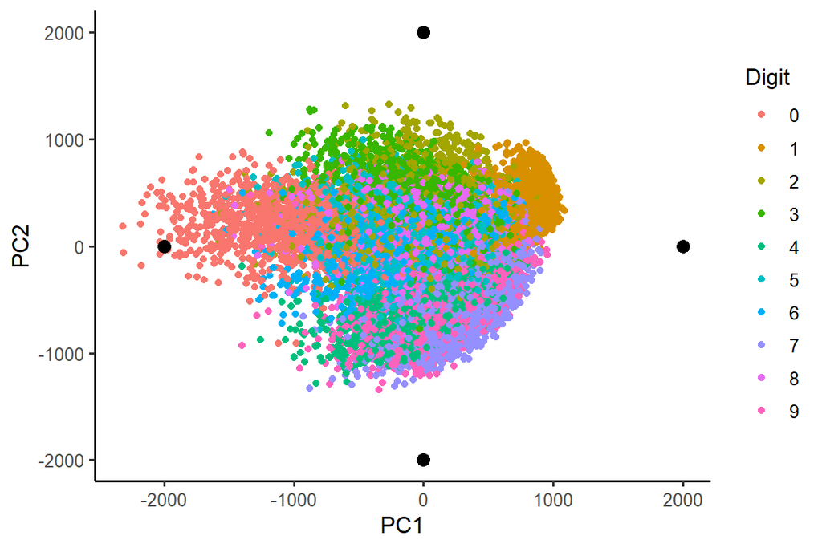

Figure 6: 4 fake digits on the PCA plane

```r
blueprints <- data.frame(PC1=c(2000,-2000,0,0),PC2=c(0,0,2000,-2000))

ggplot(pca.df)+geom_point(aes(PC1,PC2,color=factor(y_train)))+
  labs(color='Digit')+
  geom_point(data=blueprints,aes(PC1,PC2),color='black',size=3)
```

Let’s revers them and see how they look (remember that with ggimage(), white is 255 and black is 0, the opposite of image(), also there is a need of add a t() in image() )

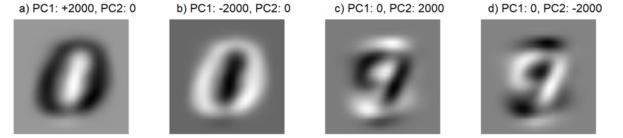

Figure 7: the ‘real’ 4 fake digits

```r
library(ggmap)
library(gridExtra)
Xhat <- as.matrix(blueprints)%*%t(pca.model$rotation[,1:2])

dim(Xhat) <- c(4,28,28)
p1 <- ggimage(Xhat[1,,])+theme(plot.margin = unit(c(0,1,0,0.5), "cm"))
p2 <- ggimage(Xhat[2,,])+theme(plot.margin = unit(c(0,1,0,0.5), "cm"))
p3 <- ggimage(Xhat[3,,])+theme(plot.margin = unit(c(0,1,0,0.5), "cm"))
p4 <- ggimage(Xhat[4,,])+theme(plot.margin = unit(c(0,1,0,0.5), "cm"))

grid.arrange(arrangeGrob(p1,top='a) PC1: +2000, PC2: 0'),
             arrangeGrob(p2,top='b) PC1: -2000, PC2: 0'),
             arrangeGrob(p3,top='c) PC1: 0, PC2: 2000'),
             arrangeGrob(p4,top='d) PC1: 0, PC2: -2000'),nrow=1)
```

From left to rigth:

1. i’m a 1, and definetly not a 0
2. i’m a 0, and definetly not a 1
3. i’m definetly not a 9 and i have some width in the bottom half.
4. i look like a 9, and i’m thin in the bottom half.

# UMAP

Umap in the other hand don’t keep all the information. In UMAP there are “only” two distance: close-far, or you are a 7, or you are not a 7, there is no such things as 7 is similar to a 1 but very different from an 8. As UMAP keeps less information, it will need less axis to plot them. But then you can not interpret the relative positions of the groups, nor the position of individual (only if they are in a group or not). (actually Umap does have this distance information between groups, but it gives to it so few weigth in the computation, that you can not rely on results) here the UMAP:

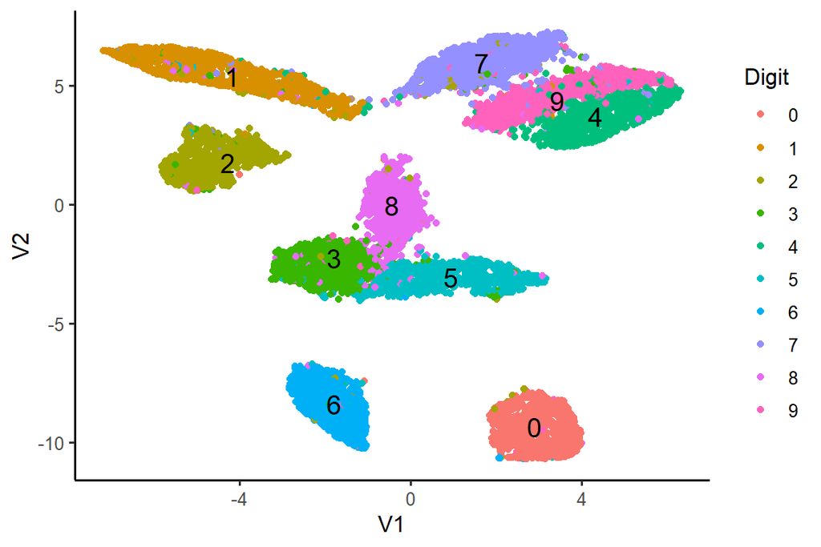

Figure 8: UMAP plot of digits-MNIST

```r
library(umap)
umap.model <- umap(x_train,verbose=T,n_components=2,n_epochs=1000)
umap.df <- as.data.frame(umap.model$layout)
umap.df$y_train <- y_train

centroid <- umap.df%>%group_by(y_train)%>%summarise(V1=mean(V1),V2=mean(V2))

ggplot(umap.df,aes(V1,V2))+geom_point(aes(color=factor(y_train)))+
  geom_text(data=centroid,aes(V1,V2,label=y_train),size=5)+labs(color='Digit')
```